# Introduction to Python Basics of Data Analysis Using Pandas

David Durden, Data Services Librarian  
Yishan Ding, Statistical Consulting Graduate Assistant

[figure not shown]

## What is Python?

- An interpreted high-level general-purpose programming language
- Both a programming language and a tool that executes scripts written in Python
- Python was created Guido van Rossum and released in 1991

## Why use Python?

- Free
- Open-source with active development
- Available on all major OS's (MacOS, Linux, Windows)
- Large community
- Easy-to-learn*
- Encourages re-use and reproducibility
- Interdisciplinary and extensible

## Species of Python

[Anaconda](https://www.anaconda.com/) is a specific distribution of Python that includes a lot of popular packages by default, including IPython console, Jupyter Notebook, Pandas, and others.

Several OS's come with Python installed by default. However, the system Python is often used by the operating system. Modifying the system Python *can* result in some programs not working correctly.

## Outline for Today's Workshop

- Some basic Python commands
- Data import and preview
- Summary statistics and reporting
- Simple plots
- Simple Linear Regression

## Set Up Your Environment

We will be using a Jupyter Notebook for this workshop to avoid having to edit text files and execute them at the Command Line.

Python can be run in interactive mode: You can type commands directly into the Python interpreter and see results. Open your Command Prompt or Terminal application and type `python`.

Using the interpreter is useful for testing code and getting immediate results. However, you cannot easily edit those commands or save your work.

### Creating Python Scripts

Instead of using the interpreter, we can also write Python programs and then run them.

To get started, use a plain text editor like:

- [BBedit](https://www.barebones.com/products/bbedit/index.html)
- [Atom](https://atom.io/)
- [Notepad++](https://notepad-plus-plus.org/)

Text documents should be set up a specific way in order to read a valid Python code.

- The first line of your document should always be: `#! /usr/bin/env python`
- Save your file with `.py`

When you have written a program, you can run it using the following basic command: `python my_program.py`

## Getting Started

- Meet the print statement
  - `print("Hello World!")`

```python
print("Hello World!")
```

```
Hello World!
```

**Fun fact**: Printing `Hello world!` to the screen is a rhetorical function used by programmers to test that their systems are operating correctly. Incidentally, this has also become one of the first programs that you learn in almost every programming language. The creation of this function is attributed to Brian Kernighan, who first published it in a code snippet in *A Tutorial Introduction to the Programming Language B* in 1973.

### Assign values to a variable

You can store anything in a variable in Python.

```python
x = 3 # Assign a single integer value
y = [1, 2, 3] # Assign a list of integer values
z = ["a", "b", "c"] # Assign a list of character values
a = [x, y] # Assign a list of variables
b = a

print(x)
print(y)
print(z)
print(a)
print(b)
```

```
3
[1, 2, 3]
['a', 'b', 'c']
[3, [1, 2, 3]]
[3, [1, 2, 3]]
```

### Using Python as a Calculator

- `35*40/4`
- `from math import sqrt`
  - `sqrt(2)`

```python
35*40/4
```

```
350.0
```

```python
from math import sqrt
sqrt(2)
```

```
1.4142135623730951
```

## 5 Basic Atomic Classes

| Class | Example |
| --- | --- |
| Integer | `3` or `int(3)` |
| Float | `3.1415` or `float(6/5)` |
| Character | `"a"`, `"b"`, `"University of Maryland"` or `str()` |
| Logical | `True`, `False` or `bool()` |
| Complex | `1+4j` or `complex(1, 4)` |

- To determine an object type, use `type()`
- To test if an object is a specific type, use `isinstance()`
- To change type, use `int()`, `float()`, `str()`, `bool()`, `complex()`

```python
type(3)
```

```
int
```

```python
type(3.1415)
```

```
float
```

```python
type("Testudo")
```

```
str
```

```python
foo = 6/5
isinstance(foo, float)
```

```
True
```

```python
complex(1, 4)
```

```
(1+4j)
```

## Pandas: The Python Data Analysis Library

[Pandas](https://pandas.pydata.org/) is already included by default in Anaconda Python. If you are using a different distribution you will have to download and install Pandas.

Pandas provides easy-to-use methods for working with data structures and performing data analysis using the Python language and enviroment.

Many of the commands and capabilities are similar to R.

```python
# To get started using Pandas we have to import it first
import pandas

# Imported libraries can be aliased to make code shorter
# and easier to type
# pd is the common alias for Pandas
import pandas as pd
# This is an optional parameter to limit the amount of
# rows printed to the screen
pd.set_option('display.max_rows', 10)
```

## Basic Commands

These are the basic commands when working with DataFrames in Pandas

- `df.max()`
- `df.min()`
- `df.mean()`
- `df.median()`
- sum
  - `df.sum()`
  - `df.cumsum()`
- var # Still need this one
- `df.std()`

### More Basic Commands

- length
  - `len(x) # Returns the length of x`
  - `df.count()`
- summary
  - `df.describe()`
- table # No direct translation
- x[] # Indexing operator?

## Import a Dataset

We will begin by importing the `GSSsubset.csv` file

Pandas uses the `read_csv()` function to import csv files.

```python
# Note that pd.read_csv is used because we imported pandas as pd
pd.read_csv("C:/Users/ysding/Dropbox/StatCon/Python Workshop/New Materials/data/GSSsubset.csv")
```

|  | id | sex | degree | income | marital | age | height | weight | hrswrk |
| --- | --- | --- | --- | --- | --- | --- | --- | --- | --- |
| 0 | 1 | MALE | BACHELOR | 60967.50 | DIVORCED | 53 | 72 | 190 | 60 |
| 1 | 2 | FEMALE | BACHELOR | 60967.50 | MARRIED | 26 | 60 | 97 | 40 |
| 2 | 4 | FEMALE | BACHELOR | 10161.25 | MARRIED | 56 | 68 | 160 | 20 |
| 3 | 14 | FEMALE | HIGH SCHOOL | 17551.25 | MARRIED | 40 | 65 | 156 | 37 |
| 4 | 16 | MALE | HIGH SCHOOL | 17551.25 | MARRIED | 56 | 66 | 210 | 6 |
| ... | ... | ... | ... | ... | ... | ... | ... | ... | ... |
| 989 | 2531 | MALE | HIGH SCHOOL | 1478.00 | NEVER MARRIED | 40 | 71 | 230 | 48 |
| 990 | 2535 | MALE | HIGH SCHOOL | 33255.00 | DIVORCED | 56 | 72 | 195 | 46 |
| 991 | 2536 | MALE | HIGH SCHOOL | 8313.75 | NEVER MARRIED | 24 | 68 | 145 | 40 |
| 992 | 2537 | MALE | HIGH SCHOOL | 27712.50 | NEVER MARRIED | 27 | 68 | 180 | 40 |
| 993 | 2538 | FEMALE | HIGH SCHOOL | 15703.75 | WIDOWED | 71 | 63 | 140 | 48 |

994 rows × 9 columns

## Let's Examine a Dataset

When importing a dataset we should assign it to a variable for future use.

Declare a variable name and assign the `read_csv()` function from earlier.

```python
# df is common short hand in Pandas for "DataFrame", which is the object type
# we are creating when importing a csv file
gss_df = pd.read_csv("C:/Users/ysding/Dropbox/StatCon/Python Workshop/New Materials/data/GSSsubset.csv")
```

### Preview the First Few Lines of a Dataset

After we assign our dataset to a variable, we can preview it with `head()`

```python
gss_df.head()
# head() can be used on any dataframe object!
```

|  | id | sex | degree | income | marital | age | height | weight | hrswrk |
| --- | --- | --- | --- | --- | --- | --- | --- | --- | --- |
| 0 | 1 | MALE | BACHELOR | 60967.50 | DIVORCED | 53 | 72 | 190 | 60 |
| 1 | 2 | FEMALE | BACHELOR | 60967.50 | MARRIED | 26 | 60 | 97 | 40 |
| 2 | 4 | FEMALE | BACHELOR | 10161.25 | MARRIED | 56 | 68 | 160 | 20 |
| 3 | 14 | FEMALE | HIGH SCHOOL | 17551.25 | MARRIED | 40 | 65 | 156 | 37 |
| 4 | 16 | MALE | HIGH SCHOOL | 17551.25 | MARRIED | 56 | 66 | 210 | 6 |

### Preivew a Dataset

`head()` let's us look at the first few lines of a file.

`tail()` will let us look that last few lines of a file.

```python
gss_df.tail()
```

|  | id | sex | degree | income | marital | age | height | weight | hrswrk |
| --- | --- | --- | --- | --- | --- | --- | --- | --- | --- |
| 989 | 2531 | MALE | HIGH SCHOOL | 1478.00 | NEVER MARRIED | 40 | 71 | 230 | 48 |
| 990 | 2535 | MALE | HIGH SCHOOL | 33255.00 | DIVORCED | 56 | 72 | 195 | 46 |
| 991 | 2536 | MALE | HIGH SCHOOL | 8313.75 | NEVER MARRIED | 24 | 68 | 145 | 40 |
| 992 | 2537 | MALE | HIGH SCHOOL | 27712.50 | NEVER MARRIED | 27 | 68 | 180 | 40 |
| 993 | 2538 | FEMALE | HIGH SCHOOL | 15703.75 | WIDOWED | 71 | 63 | 140 | 48 |

## Exercise 1

- Import the dataset `car.csv`
- Preview the dataset
  - Call the variable that you assigned to car.csv
  - Call the head() function on the DataFrame

```python
car = pd.read_csv("C:/Users/ysding/Dropbox/StatCon/Python Workshop/New Materials/data/car.csv")
```

```python
car.head()
```

|  | Make | Model | Type | Origin | DriveTrain | MSRP | Invoice | EngineSize | Cylinders | Horsepower | MPG_City | MPG_Highway | Weight | Wheelbase | Length |
| --- | --- | --- | --- | --- | --- | --- | --- | --- | --- | --- | --- | --- | --- | --- | --- |
| 0 | Acura | MDX | SUV | Asia | All | 36945.0 | 33337.0 | 3.5 | 6.0 | 265 | 17 | 23 | 4451 | 106 | 189 |
| 1 | Acura | RSX Type S 2dr | Sedan | Asia | Front | 23820.0 | 21761.0 | 2.0 | 4.0 | 200 | 24 | 31 | 2778 | 101 | 172 |
| 2 | Acura | TSX 4dr | Sedan | Asia | Front | 26990.0 | 24647.0 | 2.4 | 4.0 | 200 | 22 | 29 | 3230 | 105 | 183 |
| 3 | Acura | TL 4dr | Sedan | Asia | Front | 33195.0 | 30299.0 | 3.2 | 6.0 | 270 | 20 | 28 | 3575 | 108 | 186 |
| 4 | Acura | 3.5 RL 4dr | Sedan | Asia | Front | 43755.0 | 39014.0 | 3.5 | 6.0 | 225 | 18 | 24 | 3880 | 115 | 197 |

### Examine the Dataset

- `df.shape` where `df` is the name of your DataFrame
  - Returns row x column
- `df.describe()`
  - Returns summary report about the descriptive statistics for each variable
- `df.columns`
  - Returns a list of the column names
- `df.index`
  - Returns row information (range and step)
- `df.info()`
  - Returns list of variables, data type, count, size, etc.

### Examine the Dataset

```python
type(gss_df)
```

```
pandas.core.frame.DataFrame
```

```python
gss_df.shape
```

```
(994, 9)
```

```python
gss_df.describe()
```

|  | id | income | age | height | weight | hrswrk |
| --- | --- | --- | --- | --- | --- | --- |
| count | 994.000000 | 994.000000 | 994.000000 | 994.000000 | 994.000000 | 994.000000 |
| mean | 1271.183099 | 36887.218352 | 44.488934 | 67.414487 | 181.318913 | 42.640845 |
| std | 734.068659 | 34702.256068 | 13.126865 | 4.037741 | 41.641615 | 14.394974 |
| min | 1.000000 | 369.500000 | 19.000000 | 57.000000 | 90.000000 | 1.000000 |
| 25% | 648.250000 | 15703.750000 | 33.000000 | 64.000000 | 150.000000 | 38.000000 |
| 50% | 1254.500000 | 27712.500000 | 44.000000 | 67.000000 | 175.000000 | 40.000000 |
| 75% | 1915.750000 | 49882.500000 | 55.000000 | 70.000000 | 205.000000 | 50.000000 |
| max | 2538.000000 | 158656.952000 | 79.000000 | 79.000000 | 410.000000 | 89.000000 |

```python
gss_df.columns
```

```
Index(['id', 'sex', 'degree', 'income', 'marital', 'age', 'height', 'weight',
       'hrswrk'],
      dtype='object')
```

```python
gss_df.index
```

```
RangeIndex(start=0, stop=994, step=1)
```

```python
gss_df.info()
```

```
<class 'pandas.core.frame.DataFrame'>
RangeIndex: 994 entries, 0 to 993
Data columns (total 9 columns):
id         994 non-null int64
sex        994 non-null object
degree     994 non-null object
income     994 non-null float64
marital    994 non-null object
age        994 non-null int64
height     994 non-null int64
weight     994 non-null int64
hrswrk     994 non-null int64
dtypes: float64(1), int64(5), object(3)
memory usage: 70.0+ KB
```

## Exercise 2

- Examine the dimensions of `car.csv`
  - How many rows does this dataset have?
  - How many columns?
  - What are the variable names?
  - Generate a summary report about the descriptive statistics of each variable

```python
car.shape
```

```
(428, 15)
```

```python
car.columns
```

```
Index(['Make', 'Model', 'Type', 'Origin', 'DriveTrain', 'MSRP', 'Invoice',
       'EngineSize', 'Cylinders', 'Horsepower', 'MPG_City', 'MPG_Highway',
       'Weight', 'Wheelbase', 'Length'],
      dtype='object')
```

```python
car.describe()
```

|  | MSRP | Invoice | EngineSize | Cylinders | Horsepower | MPG_City | MPG_Highway | Weight | Wheelbase | Length |
| --- | --- | --- | --- | --- | --- | --- | --- | --- | --- | --- |
| count | 428.000000 | 428.000000 | 428.000000 | 426.000000 | 428.000000 | 428.000000 | 428.000000 | 428.000000 | 428.000000 | 428.000000 |
| mean | 32774.855140 | 30014.700935 | 3.196729 | 5.807512 | 215.885514 | 20.060748 | 26.843458 | 3577.953271 | 108.154206 | 186.362150 |
| std | 19431.716674 | 17642.117750 | 1.108595 | 1.558443 | 71.836032 | 5.238218 | 5.741201 | 758.983215 | 8.311813 | 14.357991 |
| min | 10280.000000 | 9875.000000 | 1.300000 | 3.000000 | 73.000000 | 10.000000 | 12.000000 | 1850.000000 | 89.000000 | 143.000000 |
| 25% | 20334.250000 | 18866.000000 | 2.375000 | 4.000000 | 165.000000 | 17.000000 | 24.000000 | 3104.000000 | 103.000000 | 178.000000 |
| 50% | 27635.000000 | 25294.500000 | 3.000000 | 6.000000 | 210.000000 | 19.000000 | 26.000000 | 3474.500000 | 107.000000 | 187.000000 |
| 75% | 39205.000000 | 35710.250000 | 3.900000 | 6.000000 | 255.000000 | 21.250000 | 29.000000 | 3977.750000 | 112.000000 | 194.000000 |
| max | 192465.000000 | 173560.000000 | 8.300000 | 12.000000 | 500.000000 | 60.000000 | 66.000000 | 7190.000000 | 144.000000 | 238.000000 |

### Subset the Dataset

| 1. Subset by row/column name | 2. Subset by row/column index |
| --- | --- |
| **`df.loc[rowname, colname]`** | **`df.iloc[rowindex, colindex]`** |
| - `data.loc[2, 'degree']` - `data.loc[:3,'id':'income']` - `data.loc[[1,3,5],['id', 'degree', 'income']` | - `data.iloc[1, 3]` - `data.iloc[:5,]` - `data.iloc[900:, [2,3,5,8]]` |

Refer to [this](https://cmdlinetips.com/2019/03/how-to-select-one-or-more-columns-in-pandas/) article for a more in-depth explanation of subsetting in Pandas.

```python
gss_df.loc[0:, 'sex':'income']
```

|  | sex | degree | income |
| --- | --- | --- | --- |
| 0 | MALE | BACHELOR | 60967.50 |
| 1 | FEMALE | BACHELOR | 60967.50 |
| 2 | FEMALE | BACHELOR | 10161.25 |
| 3 | FEMALE | HIGH SCHOOL | 17551.25 |
| 4 | MALE | HIGH SCHOOL | 17551.25 |
| ... | ... | ... | ... |
| 989 | MALE | HIGH SCHOOL | 1478.00 |
| 990 | MALE | HIGH SCHOOL | 33255.00 |
| 991 | MALE | HIGH SCHOOL | 8313.75 |
| 992 | MALE | HIGH SCHOOL | 27712.50 |
| 993 | FEMALE | HIGH SCHOOL | 15703.75 |

994 rows × 3 columns

### Subset the Dataset

| 3. Subset by variable name | 4. Subset by specific criteria |
| --- | --- |
| **`df['colname']`** **`df.colname`** | **`data[data['variable'] <operator> 'criteria']`** |
| - `data['id']` - `data[['id', 'degree', 'income']]` - `data.degree` | - `data[data['age'] < 50]` - `data[data['sex'] == 'MALE']` - `data[(data['age'] < 50) & (data['sex'] == 'MALE')]` |

```python
gss_df[(gss_df['age'] < 50) & (gss_df['sex'] == 'MALE')].head()
```

|  | id | sex | degree | income | marital | age | height | weight | hrswrk |
| --- | --- | --- | --- | --- | --- | --- | --- | --- | --- |
| 7 | 27 | MALE | HIGH SCHOOL | 17551.25 | SEPARATED | 35 | 70 | 180 | 40 |
| 11 | 38 | MALE | HIGH SCHOOL | 33255.00 | DIVORCED | 31 | 67 | 150 | 39 |
| 12 | 40 | MALE | BACHELOR | 73900.00 | MARRIED | 35 | 69 | 200 | 50 |
| 13 | 44 | MALE | HIGH SCHOOL | 24017.50 | NEVER MARRIED | 26 | 76 | 165 | 45 |
| 16 | 47 | MALE | JUNIOR COLLEGE | 40645.00 | NEVER MARRIED | 30 | 72 | 185 | 45 |

## Exercise 3

Using the dataset car.csv, create subsets that meet the following criteria:

- Include only cars made from USA
  - Name this new subset data to be “usacar”.
  - How many cars do this new dataset contain? Answer: 147
- Include cars that are made from USA AND their MSRP is larger than $40,000.
  - Name this new subset data to be “usa40k”.
  - How many cars do this new dataset contain? Answer: 25

```python
usacar = car[car.Origin == "USA" ]
usacar.shape[0]
```

```
147
```

```python
usa40k = car[(car.Origin == "USA") & (car.MSRP > 40000)]
usa40k.shape[0]
```

```
25
```

## Summary Report

- Summary of each variable: `df.describe()`
- Summary statistics for subgroups/categories:
  - Example question: According to this dataset, what is the average income by sex?

```python
gss_df.groupby(['sex'])[['income']].aggregate('mean')
```

| sex | income |
| --- | --- |
| FEMALE | 27300.446119 |
| MALE | 46095.814166 |

## Exercise 4

Based on the car.csv dataset, what is the average MSRP for cars made from Asia, Europe and USA, respectively?

Answer: 24741.32, 48349.80, 28377.44

```python
car.groupby("Origin")["MSRP"].mean()
```

```
Origin
Asia      24741.322785
Europe    48349.796748
USA       28377.442177
Name: MSRP, dtype: float64
```

```python
car.groupby("Origin", as_index=False)["MSRP"].mean()
```

|  | Origin | MSRP |
| --- | --- | --- |
| 0 | Asia | 24741.322785 |
| 1 | Europe | 48349.796748 |
| 2 | USA | 28377.442177 |

```python
car.groupby(["Origin"])[["MSRP"]].aggregate("mean")
```

| Origin | MSRP |
| --- | --- |
| Asia | 24741.322785 |
| Europe | 48349.796748 |
| USA | 28377.442177 |

## Plotting in Python/Pandas

We need to import `matplotlib`, a popular scientific plotting library

```python
# This command forces plots to display in Jupyter Notebooks
%matplotlib inline
# This command imports matplotlib and assigns the alias plt
import matplotlib.pyplot as plt
```

### Univariate Graph: Histogram

More information on plotting historgrams [here](https://pythonspot.com/matplotlib-histogram/)

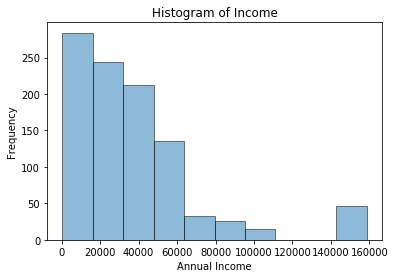

```python
# Graph the data
plt.hist(gss_df['income'], edgecolor='black', linewidth='1', alpha=0.5)
# Add title and axes labels
plt.title('Histogram of Income')
plt.xlabel('Annual Income')
plt.ylabel('Frequency')
```

### Another way to Create a Histogram

The `plot()` function is useful for when you don't want to mess with the aesthetics of graph.

```
[Text(0.5, 0, 'Annual Income')]
```

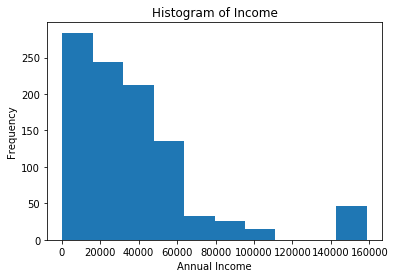

```python
gss_df['income'].plot(kind='hist', title='Histogram of Income').set(xlabel='Annual Income')
```

### Univariate Graph: Bar Chart

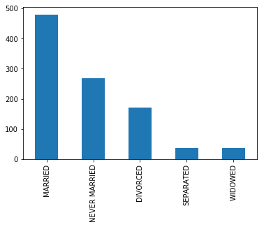

```python
# To plot a single variable on a bar chart, we need
# to count the individual values first
gss_df['marital'].value_counts().plot(kind='bar')
```

### Bivariate Graph: Scatterplot

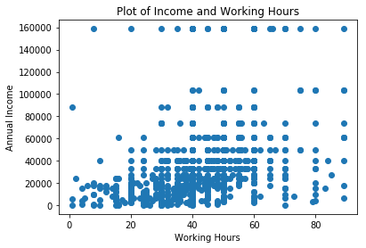

```python
# Graph the data
plt.scatter(gss_df['hrswrk'], gss_df['income'])
# Set the axes and title labels
plt.title('Plot of Income and Working Hours')
plt.xlabel('Working Hours')
plt.ylabel('Annual Income')
```

## Exercise 5

Using “car.csv”,

1. Plot a histogram on MSRP
2. Plot a bar chart on car’s Origin
3. Draw a scatter plot showing the relation between MSRP (Y axis) and Horsepower (X axis)

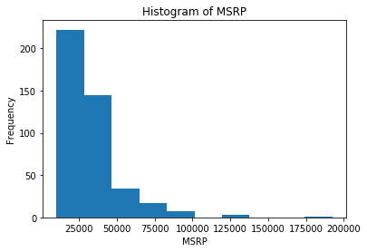

```python
plt.hist(car.MSRP)
plt.title("Histogram of MSRP")
plt.xlabel("MSRP")
plt.ylabel("Frequency")
```

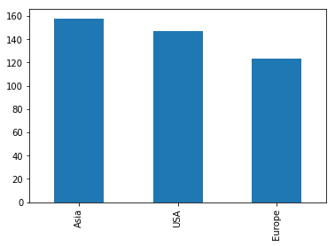

```python
car.Origin.value_counts().plot(kind = 'bar')
```

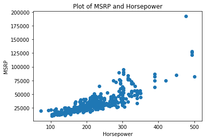

```python
plt.scatter(car.Horsepower, car.MSRP)
plt.title('Plot of MSRP and Horsepower')
plt.xlabel('Horsepower')
plt.ylabel('MSRP')
```

## Simple Linear Regression

${y} = \beta_0+\beta_1{x}+ \varepsilon $

```
- ${y}$ : dependent variable
- ${x}$ : independent variable
- $\varepsilon$ : error term
- $\beta_0$ : intercept
- $\beta_1$ : slope
```

## Simple Linear Regression

1. **F-test ${p}$-value**: *Is this model statistically significant?*
2. **${r}^2$**: *How much variance in ${y}$ can be explained by the variance in ${x}$?*
3. **Intercept**
4. **Slope**

```python
import statsmodels.formula.api as smf

# This is the easier way of implementing a linear model using
# R-like formulas
model1 = smf.ols(formula='income ~ hrswrk', data=gss_df).fit() # Note the lowercase 'ols'
print(model1.summary())                                        # Required to use patsy formulae
```

```
                            OLS Regression Results
==============================================================================
Dep. Variable:                 income   R-squared:                       0.118
Model:                            OLS   Adj. R-squared:                  0.117
Method:                 Least Squares   F-statistic:                     132.3
Date:                Tue, 17 Sep 2019   Prob (F-statistic):           7.79e-29
Time:                        12:05:10   Log-Likelihood:                -11740.
No. Observations:                 994   AIC:                         2.348e+04
Df Residuals:                     992   BIC:                         2.349e+04
Df Model:                           1
Covariance Type:            nonrobust
==============================================================================
                 coef    std err          t      P>|t|      [0.025      0.975]
------------------------------------------------------------------------------
Intercept   1621.4901   3235.485      0.501      0.616   -4727.690    7970.670
hrswrk       827.0410     71.895     11.503      0.000     685.957     968.125
==============================================================================
Omnibus:                      421.362   Durbin-Watson:                   1.708
Prob(Omnibus):                  0.000   Jarque-Bera (JB):             1713.357
Skew:                           2.027   Prob(JB):                         0.00
Kurtosis:                       7.993   Cond. No.                         141.
==============================================================================

Warnings:
[1] Standard Errors assume that the covariance matrix of the errors is correctly specified.
```

## Exercise 6

Using the car.csv data, answer the following questions:

- Run a simple linear regression explaining MSRP by Horsepower
- Using the regression output, write down the model equation as comment in your script
- Is the model significant on alpha = 0.05?

```python
mod = smf.ols('MSRP ~ Horsepower', data = car).fit()
print(mod.summary())
```

```
                            OLS Regression Results
==============================================================================
Dep. Variable:                   MSRP   R-squared:                       0.684
Model:                            OLS   Adj. R-squared:                  0.683
Method:                 Least Squares   F-statistic:                     921.4
Date:                Tue, 17 Sep 2019   Prob (F-statistic):          1.41e-108
Time:                        12:05:12   Log-Likelihood:                -4586.7
No. Observations:                 428   AIC:                             9177.
Df Residuals:                     426   BIC:                             9186.
Df Model:                           1
Covariance Type:            nonrobust
==============================================================================
                 coef    std err          t      P>|t|      [0.025      0.975]
------------------------------------------------------------------------------
Intercept  -1.552e+04   1676.466     -9.255      0.000   -1.88e+04   -1.22e+04
Horsepower   223.6894      7.369     30.355      0.000     209.205     238.174
==============================================================================
Omnibus:                      284.973   Durbin-Watson:                   1.116
Prob(Omnibus):                  0.000   Jarque-Bera (JB):             6186.310
Skew:                           2.474   Prob(JB):                         0.00
Kurtosis:                      20.956   Cond. No.                         721.
==============================================================================

Warnings:
[1] Standard Errors assume that the covariance matrix of the errors is correctly specified.
```

## Thank you!

### David Durden

✉️ durden@umd.edu  
🖥 https://lib.umd.edu/data

### Yishan Ding

✉️ ysding@umd.edu  
🖥 https://lib.umd.edu/rc/statistical-consulting